# Description of Night Lights Data

carverd@colostate.edu

# Night light Radiance

The night lights data is available from the school of mines [website.](https://eogdata.mines.edu/download_dnb_composites.html) The data is compiled as monthly averages and tile 1 represents the North American continent.

These files are very large and are compressed twice. A tool such as [7zip](https://www.7-zip.org/) will allow you to uncompressed the folder to retrieve the two images within the file.

Each image contains 518,400,000 observations. Each observations refers to a surface radiance value at one 450 meter square area on the surface of the earth. The radiance image(avg_rade9h.tif) is two gigabytes in size. The number of observation image(cf_cvg.tif) is one gigabyte in size.

Data of this size requires some additional consideration when viewing/manipulating. For the purpose of this document, all information is limited to Colorado.

## Goal

Within the document, the general information present in each image is displayed. The hope is that this helps in comprehending what can be done with the data that is captured by these monthly composite.

## Colorado Average Nightly Radiance for March 2019

For all maps you can toggle on and off the image by selecting the box below the zoom buttons. You can also select different basemaps that can help with location reference.

[interactive chart not shown]

A visual example of the surface light radiance for Colorado using a equal interval distribution. Categories are defined by taking the range in values and dividing by the number of classes.

The major metropolitan areas appear along with some smaller urban areas in the state. Generally speaking most of the state has very little night time radiance.

Areas with no observations do not have a color and the base map is visible when the image is toggled on.

By changing the visualization of the data we can see a different pattern emerge.

[interactive chart not shown]

This display of information shows an equal number of observations per group. Notice the richest yellow class represents a very large range of values relative to the other four categories. This means that the majority of the surface radiance values are at the very low end of the range of measured values.

## The data in Colorado

|  | Total Records | Number of NA values | Minimum Value | Maximum Value | Range | Median | Mean | Variance | standard Deviation |
| --- | --- | --- | --- | --- | --- | --- | --- | --- | --- |
| Colorado Data | 1614612 | 108 | 0.00999999977648258 | 319.769989013672 | 319.759989013895 | 0.259999990463257 | 0.852888080698288 | 25.7559875846009 | 5.07503572249506 |

A quick look at the summary statistics shows that this data is not normally distributed.

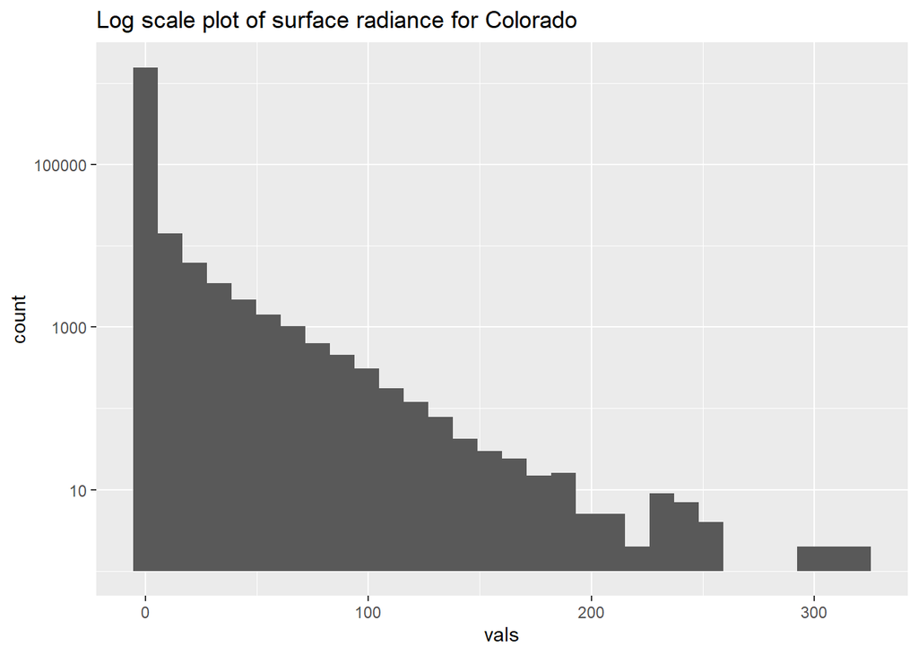

The distribution of surface radiance is considerable skewed right. There are numerous locations with very low values and some locations with high values, but not much in between.

## Dispalying the number of observations

Each image of night light radiance is an average based on all suitable measurements over the month. The number of observation used to generate the average monthly image is displayed in a second tif included in the downloaded file. This information gives you some indication on the quality of the observation. for example. A mean value based on 20 observations is much likely closer to the true value then a mean based on three observations.

[interactive chart not shown]

Generally speaking cloud cover is the most likely cause for an area to have a low number of observation. The eastern, drier half of the state has more observations then the mountain western side of the state.

## Comparing the base and light corrected nightly radiance images

On the data download site two images are available for each month

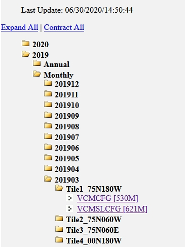

Most the the difference between the images occurs in areas that are close to the poles but we will quickly compare the images to see if surface radiance values in Colorado are different. Being consistent in what image source is used in essential for any comparisons over time.

We calculate this difference by subtracting the values in the light corrected image from the values in the base image. Any difference in surface radiance will be presented as positive or negative value. A zero value indicated that the images are the same.

[interactive chart not shown]

We can see that for the month of March 2019 there is no difference in reported surface radiance values between the base and corrected images.

## Questions

Please feel free to reach out with addational questions about how this data can be used or interpreted Dan Carver - carverd@colostate.edu